# 1. Introduction

# 3 Approach

The plot of the raw data is hard to interpret. So, we looked at the mean daily production plot.

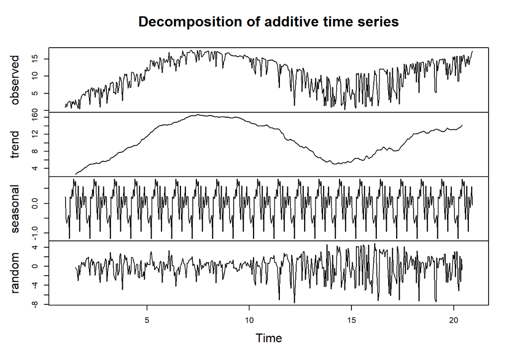

```r
decomposed<-decompose(ts(daily_prod$mean_production,freq=24))
plot(decomposed)

decomposed<-decompose(ts(daily_prod$mean_production,freq=24))
plot(decomposed)
```

Here we identify the number of days to forecast. We get the latest n_days and modify for forecasting. It creates date,hour and production columns for the upcoming days. Then, we match the actual data with forecasts.

```r
latest_available_prod_date=as.Date(max(production$date))
n_days=as.numeric(forecast_date-latest_available_prod_date)
forecasted_production=tail(production,n_days*24)
forecasted_production[,date:=date+n_days]
forecasted_production[,production:=NA]


production_with_forecast=rbind(production,forecasted_production)

forecast_table=data.table(date=forecast_date,hour=0:23,production=NA)

production_with_forecast=production_with_forecast[order(date,hour)]
production_series=ts(production_with_forecast[!is.na(production)]$production,frequency=24)

wide_weather=dcast(weather,date+hour~variable+lat+lon,value.var='value')

production_with_weather=merge(production_with_forecast,wide_weather,by=c('date','hour'))

production_with_weather[,hour:=as.character(hour)]
train_data=production_with_weather[!is.na(production)]
test_data=production_with_weather[is.na(production)]
```

#3.1 Linear Regression Model 1 We added all of the variables when establishing our first model.

```r
lm_model=lm(production~.,train_data[,-c('date'),with=F])
summary(lm_model)
```

```
##
## Call:
## lm(formula = production ~ ., data = train_data[, -c("date"),
##     with = F])
##
## Residuals:
##     Min      1Q  Median      3Q     Max
## -35.846  -3.136   0.253   3.425  21.480
##
## Coefficients:
##                               Estimate Std. Error t value Pr(>|t|)
## (Intercept)                 -6.008e+01  4.781e+00 -12.567  < 2e-16 ***
## hour1                        5.611e-02  3.936e-01   0.143 0.886645
## hour10                       1.535e+01  4.912e-01  31.253  < 2e-16 ***
## hour11                       1.364e+01  5.157e-01  26.448  < 2e-16 ***
## hour12                       1.221e+01  5.346e-01  22.842  < 2e-16 ***
## hour13                       1.107e+01  5.464e-01  20.261  < 2e-16 ***
## hour14                       9.659e+00  5.519e-01  17.501  < 2e-16 ***
## hour15                       7.911e+00  5.506e-01  14.368  < 2e-16 ***
## hour16                       6.595e+00  5.089e-01  12.959  < 2e-16 ***
## hour17                      -5.268e-01  4.820e-01  -1.093 0.274370
## hour18                      -6.082e+00  4.579e-01 -13.284  < 2e-16 ***
## hour19                      -6.852e+00  4.381e-01 -15.640  < 2e-16 ***
## hour2                        6.633e-02  3.939e-01   0.168 0.866293
## hour20                      -5.515e+00  4.240e-01 -13.007  < 2e-16 ***
## hour21                      -4.647e+00  4.138e-01 -11.232  < 2e-16 ***
## hour22                       6.894e-02  3.951e-01   0.175 0.861467
## hour23                       8.904e-03  3.938e-01   0.023 0.981960
## hour3                        8.718e-02  3.945e-01   0.221 0.825088
## hour4                        8.001e-02  3.954e-01   0.202 0.839625
## hour5                        1.349e-01  3.961e-01   0.340 0.733518
## hour6                        1.385e+00  3.967e-01   3.491 0.000483 ***
## hour7                        8.866e+00  3.959e-01  22.392  < 2e-16 ***
## hour8                        1.930e+01  3.975e-01  48.553  < 2e-16 ***
## hour9                        2.362e+01  4.031e-01  58.601  < 2e-16 ***
## quarter2                     8.995e-01  2.340e-01   3.843 0.000122 ***
## quarter3                     2.486e+00  3.123e-01   7.962 1.86e-15 ***
## quarter4                     2.205e+00  2.015e-01  10.941  < 2e-16 ***
## CLOUD_LOW_LAYER_36.25_33    -5.987e-04  5.256e-03  -0.114 0.909312
## CLOUD_LOW_LAYER_36.25_33.25 -1.829e-02  7.203e-03  -2.539 0.011128 *
```

[output cut: 25 more lines]

```
## TEMP_36.25_33                6.538e-02  1.231e-01   0.531 0.595273
## TEMP_36.25_33.25             1.039e+00  1.761e-01   5.898 3.79e-09 ***
## TEMP_36.25_33.5             -4.782e-01  1.167e-01  -4.096 4.23e-05 ***
## TEMP_36.5_33                 1.031e-01  9.726e-02   1.060 0.289059
## TEMP_36.5_33.25             -2.501e-01  1.614e-01  -1.550 0.121233
## TEMP_36.5_33.5               2.367e-02  1.052e-01   0.225 0.821980
## TEMP_36.75_33                4.622e-02  1.068e-01   0.433 0.665299
## TEMP_36.75_33.25             3.687e-01  1.420e-01   2.596 0.009441 **
## TEMP_36.75_33.5             -7.147e-01  1.132e-01  -6.315 2.80e-10 ***
## ---
## Signif. codes:  0 '***' 0.001 '**' 0.01 '*' 0.05 '.' 0.1 ' ' 1
##
## Residual standard error: 6.088 on 11433 degrees of freedom
## Multiple R-squared:  0.8211, Adjusted R-squared:  0.8201
## F-statistic: 846.1 on 62 and 11433 DF,  p-value: < 2.2e-16
```

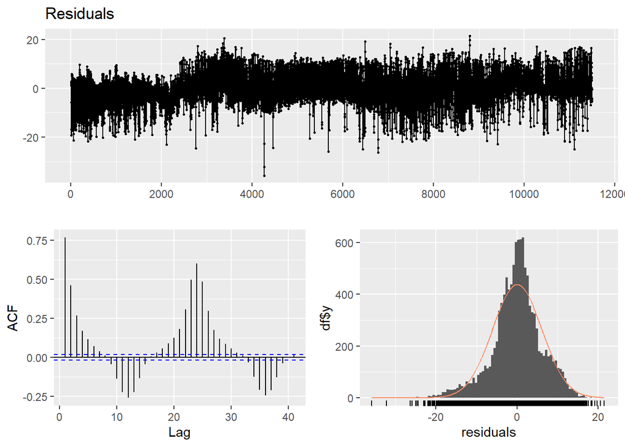

```
##
##  Breusch-Godfrey test for serial correlation of order up to 66
##
## data:  Residuals
## LM test = 8467.5, df = 66, p-value < 2.2e-16
```

```r
checkresiduals(lm_model)
```